# Implementing a Metapopulation Bass Diffusion Model using the R Package deSolve

Diffusion is a fundamental process in physical, biological, social and economic settings. Consumer products often go viral, with sales driven by the word of mouth effect, as their adoption spreads through a population. The classic diffusion model used for product adoption is the Bass diffusion model, and this divides a population into two groups of people: potential adopters who are likely to adopt a product, and adopters who have purchased the product, and influence others to adopt. The Bass diffusion model is normally captured in an aggregate form, where no significant consumer differences are modeled. This paper extends the Bass model to capture a spatial perspective, using metapopulation equations from the field of infectious disease modeling. The paper’s focus is on simulation of deterministic models by solving ordinary differential equations, and does not encompass parameter estimation. The metapopulation model in implemented in R using the *deSolve* package, and shows the potential of using the R framework to implement large-scale integral equation models, with applications in the field of marketing and consumer behaviour.

Jim Duggan (School of Engineering and Informatics, National University of Ireland Galway)  
2017-05-10

## 1 Introduction

Diffusion is a fundamental process in physical, biological, social and economic settings (Rahmandad and Sterman 2008). In the business arena, consumer products frequently go viral by the word of mouth effect between consumers. In this scenario, products experience rapid sales growth, which eventually slows as the number of potential adopters decline. A classic dynamic model to capture these growth processes is the Bass model (Bass 1969), which is based on the assumption that the timing of purchases is related to the number of previous buyers. This model provided good predictions of the sales peak, and the timing of the peak when compared to historical data. Providing model-based estimates of peak timing can assist with production capacity planning and sales distribution strategies, for example, to ensure that enough product items are available in time to match future demand. A representation of the Bass model is shown in Figure 1, and this captures the scenario whereby newer technologies are not immediately adopted by all potential buyers, and a diffusion process is set into motion (Norton and Bass 1987). This version of the Bass model is informed by standard epidemiological diffusion models(Vynnycky and White 2010), and so the term *force of persuasion* is analogous to the epidemiological term *force of infection.*

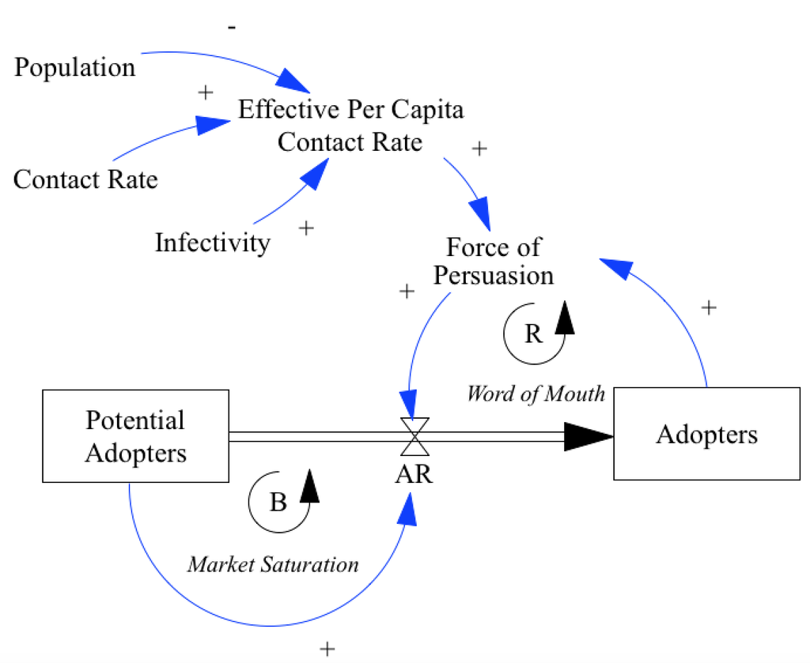

Figure 1: Market diffusion model, aggregate version. *AR* represents the adoption rate (derivative), and **+** and **-** refer to positive and negative association respectively. The symbol *B* represents a negative feedback loop (balancing), while *R* indicates a positive feedback loop (reinforcing).

The modeling methodology used in this paper is system dynamics (Sterman 2000; Duggan 2016), a method for modeling social systems, which focuses on how feedback structures (i.e. causal loops) impact overall system behavior. Feedback is a defining element of system dynamics (Lane 2006), where a feedback loop is a chain of circular causal links represented in a model. There are two types of feedback which impact a variable: *negative feedback* which opposes the direction of change in a loop variable (for example, a theromstat controller that regulates heat in a room), whereas *positive feedback* amplifies a variable’s value, as in the case of the *contagion effect* in infectious disease spread. At a technical level, system dynamics models are solved using integration, where integrals are referred to as stocks, and derivatives are modeled as flows. System dynamics diagrams are intuitive, as they present a dynamic system in terms of the stocks (containers), and flows (valves), which control the rate at which stocks fill and drain over time.

## 2 Bass diffusion model

The Bass diffusion model has two integrals: *Potential Adopters* (1), which model individuals in the population that have yet to acquire a product, and *Adopters* (2), which represent people who have purchased a product, and are in a position to influence others to initiate a purchase. For this paper, the initial values of these stocks are $99,999$ and $1$ respectively, giving a total population size of $100,000$. These initial values will also be maintained across the metapopulation model, which provides a useful basis for comparing the outputs of both models.

$$\label{eq1}
Potential Adopters = \int_{0}^{t} -AR\hspace{.2cm} dt \tag{1}$$

$$\label{eq2}
Adopters= \int_{0}^{t} AR \hspace{.2cm}dt \tag{2}$$

The flow equation $AR$ (8) captures a number of concepts. First, there is the idea of the effective per capita contact rate, known by the parameter $\beta$ (3), which is based on:

- The contact rate (4) between members of the population, which is an estimate of how often people interact.
- The infectivity (5) of these interactions, which is a way of modeling how likely it is for an individual to be convinced to purchase, based on an interaction with an adopter.
- The total population (6), which is the denominator of the equation.

$$\label{eq3}
\beta = \frac{Contact Rate \times Infectivity}{Population} \tag{3}$$

$$\label{eq4}
Contact Rate= 3 \tag{4}$$

$$\label{eq5}
Infectivity = 0.15 \tag{5}$$

$$\label{eq6}
Population=100,000 \tag{6}$$

Given the value for $\beta$, it is then possible to calculate the force of persuasion $\rho$, which defines the proportion of potential adopters that will convert at each time period. This equation (7) is similar to the epidemiological term known as the *attack rate*, which determines how many susceptible people become infected per time period in classic infectious disease models (Anderson et al. 1991).

$$\label{eq7}
\rho=\beta \times Adopters \tag{7}$$

With the value for $\rho$ evaluated, the adoption rate is simply the product of this value with the number of potential adopters in the population, as shown in (8).

$$\label{eq8}
AR= \rho \times Potential Adopters \tag{8}$$

These equations have three properties that add to the robustness of the model, These are:

- if there are no contacts in the population, $\beta$ will equal 0, and no adoption will occur;
- if infectivity is zero, $\beta$ will also equal 0, which will stop any adoption;
- if there are no adopters, then the force of persuasion will be zero, and no adoptions will occur.

Equations (1)-(8) can be implemented using the [*deSolve*](https://CRAN.R-project.org/package=deSolve) package (Soetaert et al. 2010; Soetaert et al. 2016), which solves initial value problems written as ordinary differential equations (ODE), differential algebraic equations (DAE), and partial differential equations (PDE). For modeling diffusion processes, the R package EpiDynamics (Baquero and Marques 2015) was also considered, however it does not currently provide functionality to solve two-compartment SI models, which forms the basis of the Bass model. The R package [*EpiModel*](https://CRAN.R-project.org/package=EpiModel) (Jenness et al. 2016) also contains an API that is flexible to formulate a number deterministic compartmental models. For our scenario, the ODE solver in *deSolve* is used, where the differential equations are encapsulated in a function.

The initial segment of code[^1] loads the packages, sets the simulation start time, finish time, and time step, and constructs the appropriate time vector that is needed by *deSolve*. Following that, the two integrals (stocks) are created, along with their initial values, and auxiliary parameters initialised within a vector. In naming variables, Hungarian Notation (Li and Prasad 2005) is used, to distinguish between stocks (s), flows (f) and exogenous parameters (a), known in system dynamics as auxiliaries.

```r
library(deSolve)

START   <- 0; FINISH <- 50; STEP <- 0.01;
simtime <- seq(START, FINISH, by=STEP)

stocks  <- c(sPotentialAdopters=99999,sAdopters=1)
auxs    <- c(aTotalPopulation=100000, aContact.Rate=3, aInfectivity=0.15)
```

Next the function containing the model equations is constructed. This is called by the *deSolve* framework for every solution step of the ODE, and the parameters passed in include:

- The current simulation time,
- A vector containing all integrals (stocks) and their values,
- A vector containing the parameters used in the stock and flow model.

The R code for the function is shown below, and the corresponding model equations are also referred to.

```r
model <- function(time, stocks, auxs){
  with(as.list(c(stocks, auxs)),{
    aBeta   <- aContact.Rate * aInfectivity/ aTotalPopulation    # Eqn (3)
    aRho    <- aBeta * sAdopters                                 # Eqn (7)
    fAR     <- sPotentialAdopters * aRho                         # Eqn (8)
    dPA_dt  <- -fAR                                              # Eqn (1)
    dA_dt   <- fAR                                               # Eqn (2)

    return (list(c(dPA_dt, dA_dt),
                 AR=fAR, Rho=aRho))
  })
}
```

```r
o<-data.frame(ode(y=stocks, times=simtime, func = model,
                  parms=auxs, method="euler"))
```

Figure 2 shows the classic behavior of the Bass model, as the dynamics of the adopter exhibit s-shaped growth as the customer base saturates to its maximum possible value over time.

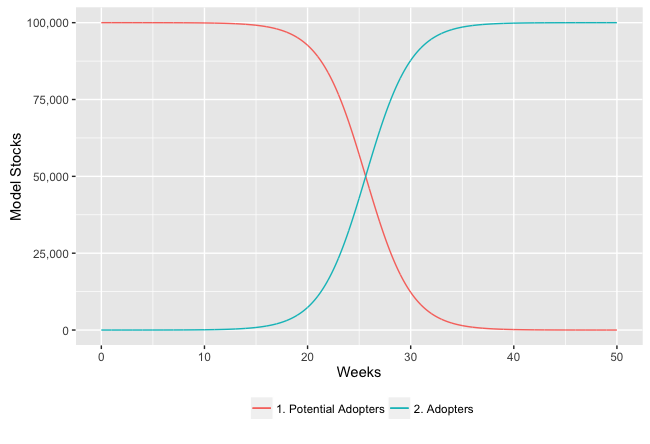

Figure 2: Simulation of the Bass model

In summary, the aggregate model is useful to capture the overall dynamics of the diffusion process. However, for spatial diffusion models a revised equation structure is needed, and one such model based on the dynamics of infectious disease transmission - is now described.

## 3 Metapopulation diffusion model

Metapopulation structures are a powerful feature in dynamic modeling, as they facilitate the investigation of finer-grained behaviours and dynamics than can be achieved through an aggregate model. The metapopulation concept is to subdivide the entire population into distinct *subpopulations*, each with independent dynamics, and combine this with limited interaction between each subpopulation (Keeling and Rohani 2008). The approach is appropriate if there are significant variations in model parameters across the population. For example, in disease dynamics, empirical studies show non-random mixing in populations, including data on the transmission of tuberculosis (Borgdorff et al. 1999), and contact patterns across Europe show highly assortative mixing patterns with age (Mossong et al. 2008). A similar argument can be made for product adoption models, and for this scenario, a regional spatial structure is proposed as the main mechanism for subdividing the model. Figure 3 shows a hypothetical regional structure, where the population centers (colours reflect population density) are in the middle of the region, and models an unbalanced regional development which is a feature of many countries.

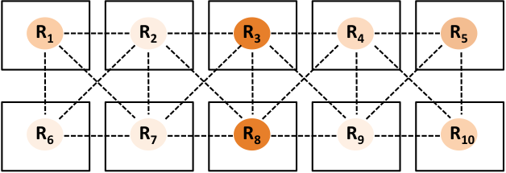

Figure 3: Spatial structure for metapopulation diffusion model

Out of an overall population of 100,000, the proportions in each region are captured in Table 1.

Table 1: Population proportions by region

| R1 | R2 | R3 | R4 | R5 | R6 | R7 | R8 | R9 | R10 |
| --- | --- | --- | --- | --- | --- | --- | --- | --- | --- |
| 10% | 1% | 21% | 8% | 17% | 4% | 5% | 25% | 3% | 6% |

$$\label{eq9}
AR_i= \rho_i \times Potential Adopters_i \tag{9}$$

The force of persuasion $\rho_i$ reflects the spatial properties of the model, and is a weighted sum of the per capita effective contact rates from region $j$ to region $i$, multiplied by the number of adopters ($A_j$) in region $j$ (10). This structure is based on standard epidemiological transmission equations between cohorts, where the $j^{th}$ cohort is infectious (an adopter), and the $i^{th}$ cohort is susceptible (a potential adopter).

$$\label{eq10}
\rho_i= \sum\limits_{j=1}^N \beta_{ij}.A_j \tag{10}$$

Equation (10) can also be conveniently expressed in matrix form, as shown in (11).

$$\label{eq11}
\begin{pmatrix}
\rho_1\\
\rho_2\\
\vdots \\
\rho_N
\end{pmatrix}=
\begin{pmatrix}
\beta_{11}&\beta_{12}&\dots&\beta_{1N}\\
\beta_{21}&\beta_{22}&\dots&\beta_{2N}\\
\vdots & \vdots &\ddots&\vdots \\
\beta_{N1}&\beta_{N2}&\dots&\beta_{NN}\\
\end{pmatrix}
\begin{pmatrix}
A_1\\
A_2\\
\vdots\\
A_N
\end{pmatrix} \tag{11}$$

The $\beta$ component, originally introduced in (3), is the effective contact rate per capita, and therefore the square matrix component of (11) can be further factored into (12) which shows the transmission calculations between each region. The denominator is the same for each matrix row, and is the population of each region containing the potential adopters.

$$\label{eq12}
\beta_{ij} = e_{ij} / N_i \tag{12}$$

The effective contact values ($e$) are based on the contact rates between the different sectors. The contact rates are calculated from the normal contact rate for a region ($n$), multiplied by a distancing weighting measure using a power law function (Brockmann et al. 2006), useful for individual-based models (Mungovan et al. 2011; Liu et al. 2012), given that these structures have also been successfully implemented in models of infectious disease (Meyer et al. 2014). This equation is shown in (13), and the distance is the Euclidean distance function that uses the grid coordinates as a reference (14), given the points ($x_1$,$y_1$) and ($x_2$,$y_2$ ).

$$\label{eq13}
c_{ij} = n_j \cdot (d_{ij} + 1)^{-\alpha} \tag{13}$$

$$\label{eq14}
d_{ij}= \sqrt{(x_2-x_1)^2+(y_2-y_1)^2} \tag{14}$$

To provide flexibility for experimentation, the parameter $\alpha$ (15) provides scope to moderate the contact rates between the different regions. With $\alpha$ =0, the contact rates do not change from the original region to other regions, whereas higher values will cause contact rates to decrease as the distance between regions increases.

$$\label{eq15}
\alpha \geq 0 \tag{15}$$

The effective contact rates ($e$), which model the word of mouth effect from region to region is shown in (16), which is the product of the contact rates ($c$) and infectivity ($f$), which models the probability of transmission. This equation provides the necessary information to process the matrix specified in (11).

$$\label{eq16}
e_{ij} = c_{ij} . f_j \tag{16}$$

Table 2: Sample normal contact rates ($n$) per area, weighted by population density

| R1 | R2 | R3 | R4 | R5 | R6 | R7 | R8 | R9 | R10 |
| --- | --- | --- | --- | --- | --- | --- | --- | --- | --- |
| 4.58 | 0.56 | 10.12 | 4.61 | 10.00 | 1.64 | 2.53 | 14.46 | 1.53 | 2.95 |

Table 3: Sample infectivity probabilities ($f$), by region (uniform random numbers)

[output not shown]

Table 4: Regional distance matrix based on Euclidean distance

|  | R1 | R2 | R3 | R4 | R5 | R6 | R7 | R8 | R9 | R10 |
| --- | --- | --- | --- | --- | --- | --- | --- | --- | --- | --- |
| R1 | 0.00 | 1.00 | 2.00 | 3.00 | 4.00 | 1.00 | 1.41 | 2.24 | 3.16 | 4.12 |
| R2 | 1.00 | 0.00 | 1.00 | 2.00 | 3.00 | 1.41 | 1.00 | 1.41 | 2.24 | 3.16 |
| R3 | 2.00 | 1.00 | 0.00 | 1.00 | 2.00 | 2.24 | 1.41 | 1.00 | 1.41 | 2.24 |
| R4 | 3.00 | 2.00 | 1.00 | 0.00 | 1.00 | 3.16 | 2.24 | 1.41 | 1.00 | 1.41 |
| R5 | 4.00 | 3.00 | 2.00 | 1.00 | 0.00 | 4.12 | 3.16 | 2.24 | 1.41 | 1.00 |
| R6 | 1.00 | 1.41 | 2.24 | 3.16 | 4.12 | 0.00 | 1.00 | 2.00 | 3.00 | 4.00 |
| R7 | 1.41 | 1.00 | 1.41 | 2.24 | 3.16 | 1.00 | 0.00 | 1.00 | 2.00 | 3.00 |
| R8 | 2.24 | 1.41 | 1.00 | 1.41 | 2.24 | 2.00 | 1.00 | 0.00 | 1.00 | 2.00 |
| R9 | 3.16 | 2.24 | 1.41 | 1.00 | 1.41 | 3.00 | 2.00 | 1.00 | 0.00 | 1.00 |
| R10 | 4.12 | 3.16 | 2.24 | 1.41 | 1.00 | 4.00 | 3.00 | 2.00 | 1.00 | 0.00 |

Table 5: Final contact rates ($c$) from region to region, with $\alpha$ = 1.00

|  | R1 | R2 | R3 | R4 | R5 | R6 | R7 | R8 | R9 | R10 |
| --- | --- | --- | --- | --- | --- | --- | --- | --- | --- | --- |
| R1 | 4.58 | 0.28 | 3.37 | 1.15 | 2.00 | 0.82 | 1.05 | 4.47 | 0.37 | 0.58 |
| R2 | 2.29 | 0.56 | 5.06 | 1.54 | 2.50 | 0.68 | 1.26 | 5.99 | 0.47 | 0.71 |
| R3 | 1.53 | 0.28 | 10.12 | 2.31 | 3.33 | 0.51 | 1.05 | 7.23 | 0.63 | 0.91 |
| R4 | 1.14 | 0.19 | 5.06 | 4.61 | 5.00 | 0.39 | 0.78 | 5.99 | 0.77 | 1.22 |
| R5 | 0.92 | 0.14 | 3.37 | 2.31 | 10.00 | 0.32 | 0.61 | 4.47 | 0.63 | 1.47 |
| R6 | 2.29 | 0.23 | 3.13 | 1.11 | 1.95 | 1.64 | 1.26 | 4.82 | 0.38 | 0.59 |
| R7 | 1.90 | 0.28 | 4.19 | 1.43 | 2.40 | 0.82 | 2.53 | 7.23 | 0.51 | 0.74 |
| R8 | 1.41 | 0.23 | 5.06 | 1.91 | 3.09 | 0.55 | 1.26 | 14.46 | 0.77 | 0.98 |
| R9 | 1.10 | 0.17 | 4.19 | 2.31 | 4.14 | 0.41 | 0.84 | 7.23 | 1.53 | 1.47 |
| R10 | 0.89 | 0.13 | 3.13 | 1.91 | 5.00 | 0.33 | 0.63 | 4.82 | 0.77 | 2.95 |